# Buoy Observations of Air And Sea Temperatures in The Southern Bering Sea

3/9/2018

## Air Temperature

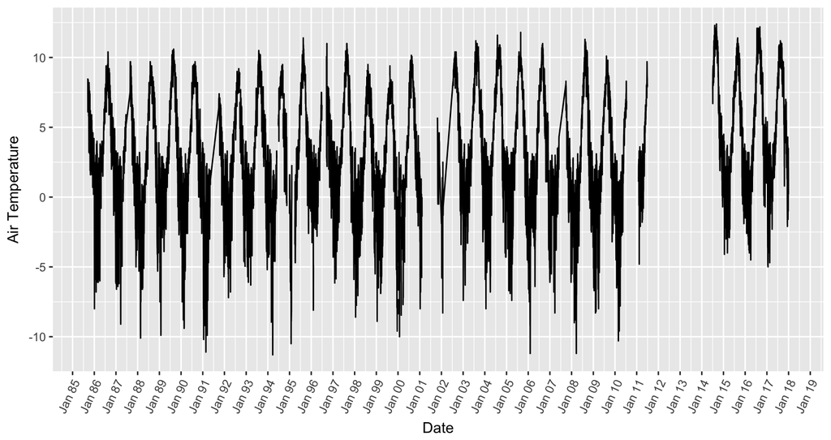

- There is a seasonal pattern repeating every year, and generally the air temperature is between -10ºC and 10ºC.

## Has the mean air temperature changed for past 30 years?

- We used the mean air temperature every year to conduct a one-way ANOVA test to see if it changes over time.

\[H_{0}: \mu_{1985} = \mu_{1986} = \mu_{1987} = ... = \mu_{2017}\] \[H_{a}: At\ least\ one\ of\ the\ means\ is\ different\]

```
##
##  One-way analysis of means (not assuming equal variances)
##
## data:  ATMP and Year
## F = 31.853, num df = 30.0, denom df = 2773.4, p-value < 2.2e-16
```

- With a significance level of 0.05, the result of the test suggests that there is statistically significant change in mean air temperature in the past 30 years.

## Sea Temperature

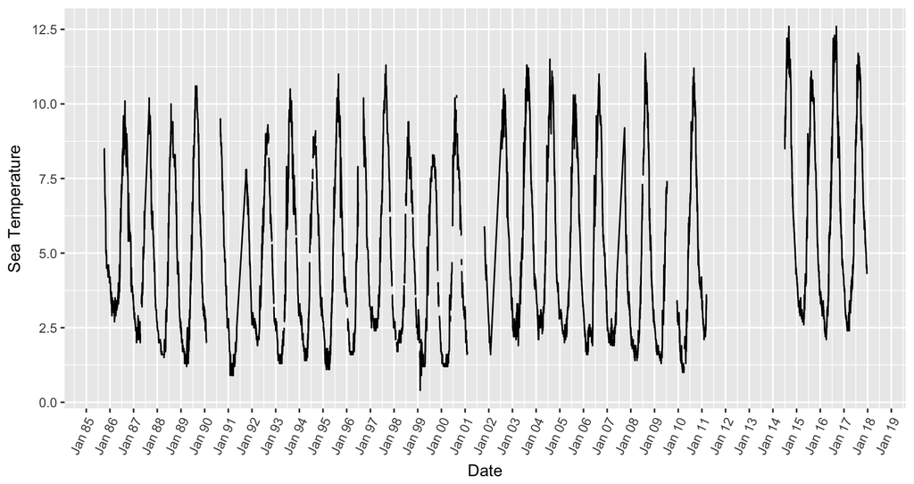

- There is a seasonal pattern repeating every year, and generally the sea temperature is always above 0ºC.

## Has the mean sea temperature changed for past 30 years?

- We used the mean sea temperature every year to conduct a one-way ANOVA test to see if it changes over time.

\[H_{0}: \mu_{1985} = \mu_{1986} = \mu_{1987} = ... = \mu_{2017}\] \[H_{a}: At\ least\ one\ of\ the\ means\ is\ different\]

```
##
##  One-way analysis of means (not assuming equal variances)
##
## data:  WTMP and Year
## F = 97.352, num df = 30.0, denom df = 2600.8, p-value < 2.2e-16
```

- With a significance level of 0.05, the result of the test suggests that there is statistically significant change in mean sea temperature in the past 30 years.

## Relationship Between Air Temperature and Sea Temperature

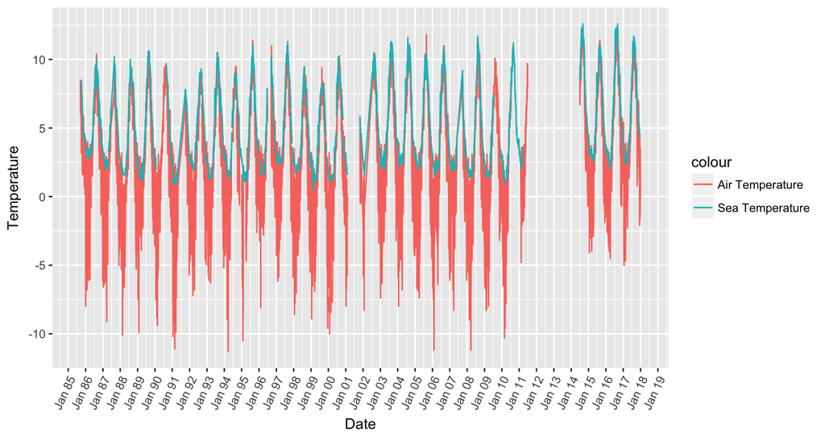

## Relationship Between Air and Sea Temperatures (Cont.)

- The previous plot shows that air and sea temperatures are highly correlated, as they two follow a very similar pattern over time. In addition, the sea temperature is always above 0ºC and is generally higher than the air temperature each day.
- A further check for the correlation between two variables with the following code yields the result of 0.8733613, which confirms our findings from the plot.

  `cor(tidy$ATMP, tidy$WTMP, use = 'complete.obs')`